# La distribución normal

Jordan Golubov y José Arévalo

23/9/2021

# Estadística descriptiva

La estadística descriptiva es el inicio de cualquier análisis de datos. Creo que la parte más importante es la visualización de los datos de forma gráfica y los índices de tendecia central (media, moda, varianza, desviación estándar, promedio).

La estadística descriptiva se divide en dos grandes rubros, las medidas de tendencia central (media, moda, mediana) y las medidas de dispersión (coeficiente de variación, varianza).

## Promedio aritmético

EL promedio se define como

$$\mu = \frac{\sum\limits_{i=1}^n
x_{i}}{n}$$

donde $x_{i} =$ valores de una variable numérica contínua, n = número de observaciones

### Ejemplo

```r
tiempo <- c(98,71,111,110,22,107,114,86,78,8,73,33,21,145,
            121,35,143,120,15,94,140,77,70,47,60,120,90)
tiempo
```

```
##  [1]  98  71 111 110  22 107 114  86  78   8  73  33  21 145 121  35 143 120  15
## [20]  94 140  77  70  47  60 120  90
```

```r
suma.de.tiempo <- sum(tiempo)
suma.de.tiempo
```

```
## [1] 2209
```

```r
numero.de.datos <- length(tiempo)
numero.de.datos
```

```
## [1] 27
```

```r
promedio <- suma.de.tiempo/numero.de.datos
promedio
```

```
## [1] 81.81481
```

## Mediana

La mediana se define como el número en el cual divide un conjunto de número a la mitad. Básicamente lo que tenemos que hacer es ordenar los números (mayor a menor o de menor a mayor, o importa)

### Calculando la mediana

```r
tiempo.ordenado <- sort(tiempo)
tiempo.ordenado
```

```
##  [1]   8  15  21  22  33  35  47  60  70  71  73  77  78  86  90  94  98 107 110
## [20] 111 114 120 120 121 140 143 145
```

```r
length(tiempo.ordenado)
```

```
## [1] 27
```

```r
tiempo.ordenado[14]
```

```
## [1] 86
```

```r
quantile(tiempo.ordenado,c(0.25,0.5,0.75))
```

```
##   25%   50%   75%
##  53.5  86.0 112.5
```

```r
summary(tiempo.ordenado)
```

```
##    Min. 1st Qu.  Median    Mean 3rd Qu.    Max.
##    8.00   53.50   86.00   81.81  112.50  145.00
```

# Medidas de dispersión

Mientras la media y la mediana nos dan información acerca de la tendencia central de los datos no nos dicen nada sobre la distribución de los datos. Por ejemplo, podemos tener dos distribuciones diferentes con los mismo valores de tendencia central

```r
variable.1 <- c(-10,0,10,20,30)
variable.2 <- c(8,9,10,11,12)
mean(variable.1)
```

```
## [1] 10
```

```r
mean(variable.2)
```

```
## [1] 10
```

## Varianza

La varianza es una medida de dispersión de los datos y en palabras simples es el promedio de cuanto se desvian los datos del promedio.

$$\sigma^{2} = \frac{\sum\limits_{i=1}^n
(x_{i}-\mu)^{2}}{n}$$

Las medidas de la $\sigma^{2}$ son en unidades al cuadrado que intuitivamente son complicadas

## Desviación Estándar

La desviación estándar es una medida de qué tal lejos se encuentra cada muestra del promedio de la población.

En términos esta´disticos, por lo general se describe el promedio y su desviación estándar o su error estándar.

Para calcular la desviación estándar de una muestra tenemos

$\sigma = \sqrt{\frac{\sum{(x_{i} - \bar{x})^{2}}}{N-1}}$

La magnitud de la desviación estándar nos dice algo acerca de la dispersión, de los datos, de tal manera que una desviación estándar pequeña nos dice que los datos se parecen a la media y una desviación grande nos dice que los datos se parecen menos a la media.

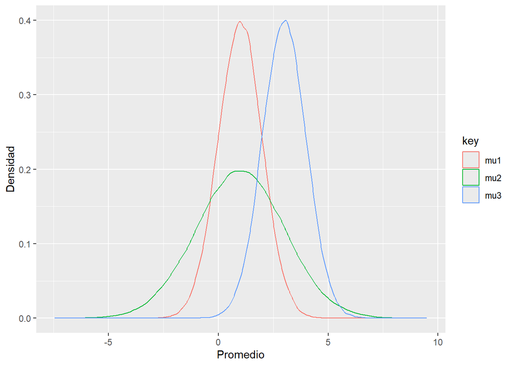

```r
tibble(mu1, mu2, mu3) %>% gather() %>% ggplot() +
  geom_density(aes(x = value, colour = key)) +
  labs(x = 'Promedio', y = 'Densidad')
```

Podemos ver que mu1 y mu2 tiene el mismo promedio pero diferente desviación estpandar mientras que mu3 tiene un promedio diferente que mu1 pero la misma desviación estándar.

# La distribución normal estandarizada

Primero tenemos que transformar nuestros datos, es decir aplicamos lo siguiente

$$z = \frac{y-x}{s}$$

Donde $s = desviacion\ estandar$, $y = valor\ del\ dato$ y $x = promedio\ de\ la\ muestra$

Una de las características de la distribución normal estandarizada es que tiene promedio = 0 y desviación estándar = 1.

La distribución normal (y la estandarizada) es una de las distribuciones más utilizadas en el análisis de datos. El teorema central del límite nos dice que si tenemos una conjunto grande de variables independientes con media conocida y desviación conocida entonces la función de normal o Gaussiana se aproxima bien a la frecuencia de los datos. Si tenemos un ejemplo

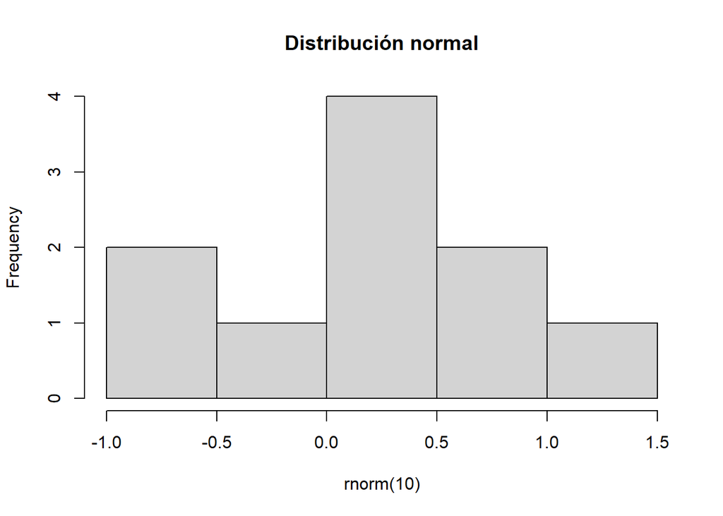

```r
hist(rnorm(10), main = "Distribución normal")
```

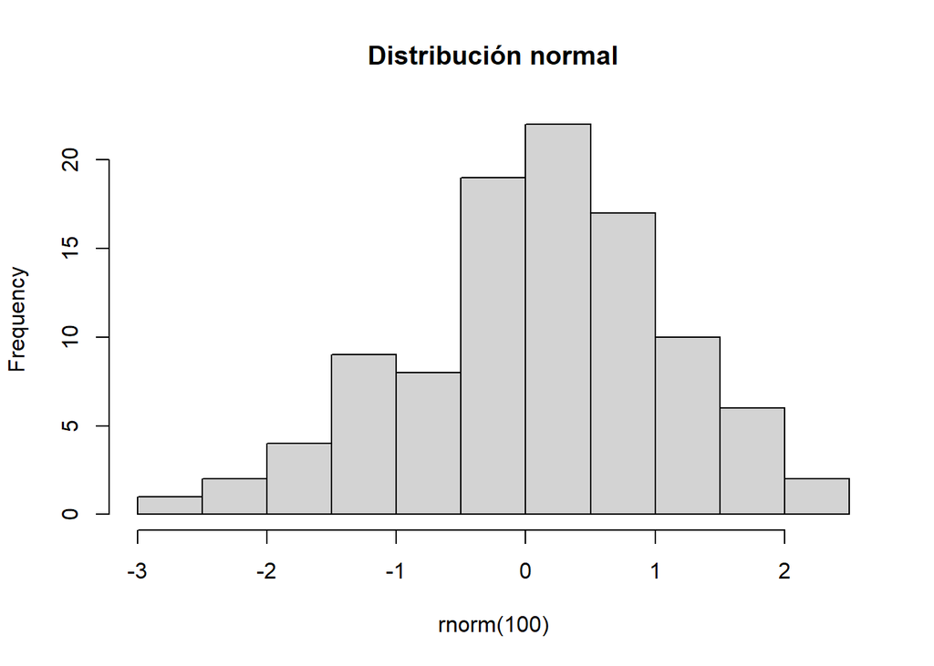

```r
hist(rnorm(100), main = "Distribución normal")
```

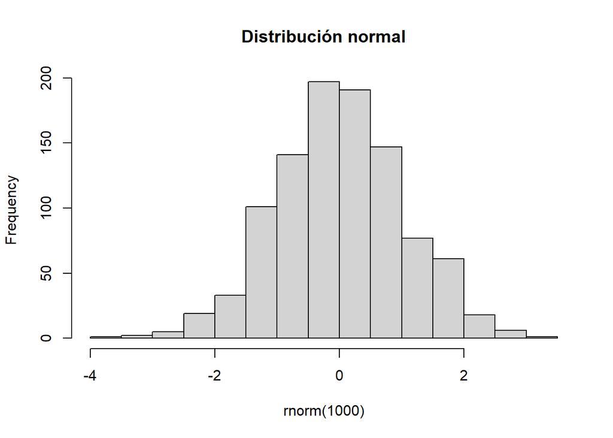

```r
hist(rnorm(1000), main = "Distribución normal")
```

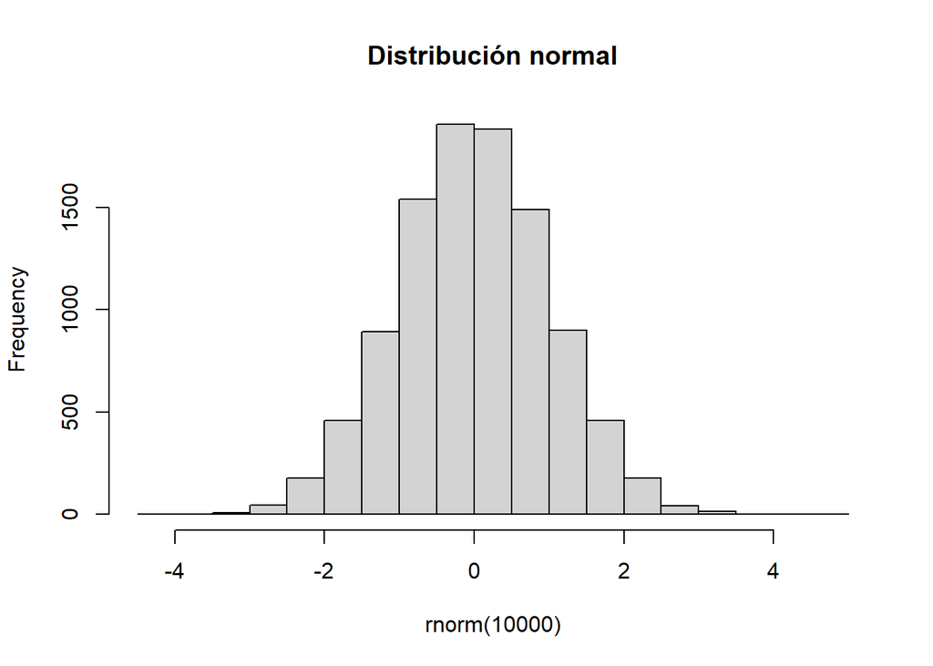

```r
hist(rnorm(10000), main = "Distribución normal")
```

La distribución normal es una forma simple que da mucha información. La regla empírica tienen una regla básica que podemos explotar para encontrar patrones. La regla es relativamente simple

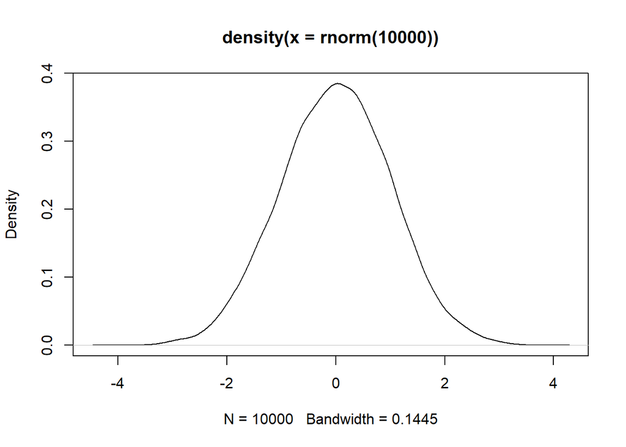

```r
plot(density(rnorm(10000)))
```

The regla empírica es tambien conocida como la regla 68-95-99.7%. Supongamos que hacemos un examen y encontramos que las calificaciones tienen un promedio de 67 y una desviación estándar de 9. Podemos deducir que aproximadamente 68% de las calificaciones se encuentran entre 58 y 76, cerca del 95% caen dentro de 49 y 85, y casi todas las calificaciones (99.7%) se encuentran entre 40 and 94.

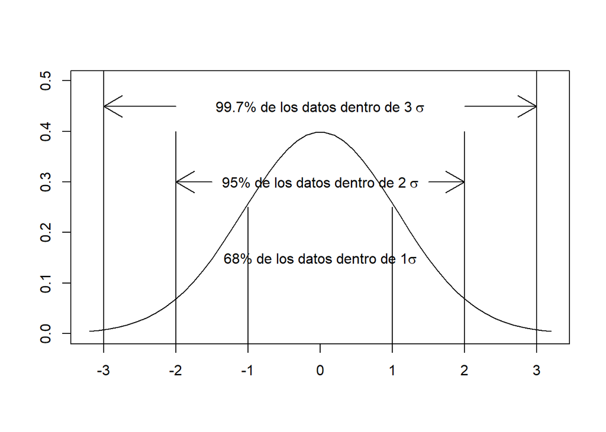

```r
plot(seq(-3.2,3.2,length=50),dnorm(seq(-3,3,length=50),0,1),type="l",xlab="",ylab="",ylim=c(0,0.5))
segments(x0 = c(-3,3),y0 = c(-1,-1),x1 = c(-3,3),y1=c(1,1))
text(x=0,y=0.45,labels = expression("99.7% de los datos dentro de 3" ~ sigma))
arrows(x0=c(-2,2),y0=c(0.45,0.45),x1=c(-3,3),y1=c(0.45,0.45))
segments(x0 = c(-2,2),y0 = c(-1,-1),x1 = c(-2,2),y1=c(0.4,0.4))
text(x=0,y=0.3,labels = expression("95% de los datos dentro de 2" ~ sigma))
arrows(x0=c(-1.5,1.5),y0=c(0.3,0.3),x1=c(-2,2),y1=c(0.3,0.3))
segments(x0 = c(-1,1),y0 = c(-1,-1),x1 = c(-1,1),y1=c(0.25,0.25))
text(x=0,y=0.15,labels = expression("68% de los datos dentro de 1" * sigma))
```

# El error estándar

La siguiente medida asociada a la desviación estándar es el error estándar. El error estándar es una medida tambien llamada el error estándar de la media. Es decir es una medida de la precisión de nuestra estimación del promedio. La distribución del una muestreo de el promedio de una población (es decir se muestrean muchas poblaciones y se obtienen los promedios de cada uno de estos). Esto genera una distribución de los diferentes promedio la cual tiene su media y varianza. A partir de aquí podemos calcular el error asociado como

$\bar{\sigma_{x}} = \frac{\sigma}{\sqrt{n}}$

Nótese que el error estándar tiende a 0 conforme se incremento el tamaño de la muestra. El error estándar de la media se usa para contruir intervalos de confianza alrededor del promedio.